# R u Ready? HS2025 | Psychologie der Digitalisierung - Einheit 3

Sandra Grinschgl, Aaron Friedli, Lars Schilling

## R u Ready? Reproduzierbare Datenaufbereitung und -analyse mit R

HS 2025  
**LV-Leitung**: Dr. Sandra Grinschgl / MSc. Aaron Friedli  
**Tutor**: BSc. Lars Schilling  
**3. Einheit**, 01.10.2025

## Fragen zum Datenanalyseplan:

[figure not shown]

## Fragen zu den Hands On Übungen der ersten beiden Wochen?

- Was hat euch Schwierigkeiten bereitet?
- Welche Übungen sollen wir gemeinsam live durchgehen?
- Gibt es noch Unklarheiten?
- **Musterlösungen ab jetzt online für Block 1!**

## Heute:

[interactive chart not shown]

## Peer-Pairings

**siehe Liste auf Ilias**

## Forschungsdatenmanagement:

*Planung, Organisation, Speicherung, Dokumentation und Archivierung von Daten während des gesamten Forschungsprozesses*

### *Warum Datenmanagemen*t:

- Datenflut in der Forschung
- Risiken ohne gutes Management

### Ziele von Datenmanagement:

- Qualitätssicherung
- Sicherheit/Datenschutz & Ethik
- Reproduzierbarkeit
- Nachhaltigkeit und Transparenz

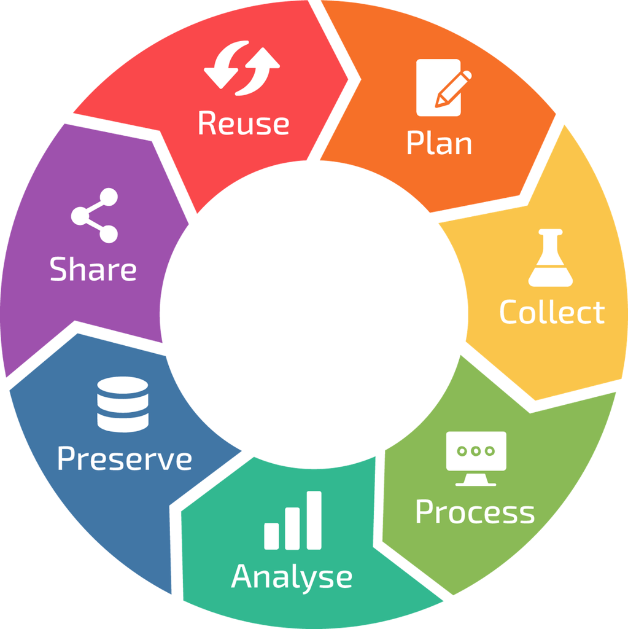

## Forschungsdatenmanagement (2)

### **Standards & Vorgaben:**

- Fair Prinzipien
- Data Management Plan (SNF)
- Förderorganisationen & Journals

**Praktische Umsetzung:**

- Ordnerstrukturen & Versionierung
- Dokumentation (README, Codebooks)
- Offene Dateiformate

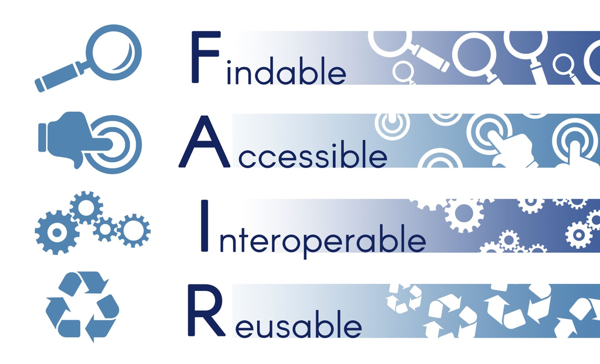

## Ordnerstrukturen: Psych-DS

- Standard für die Organisation von Daten, Skripten und weiteren Studiendokumenten

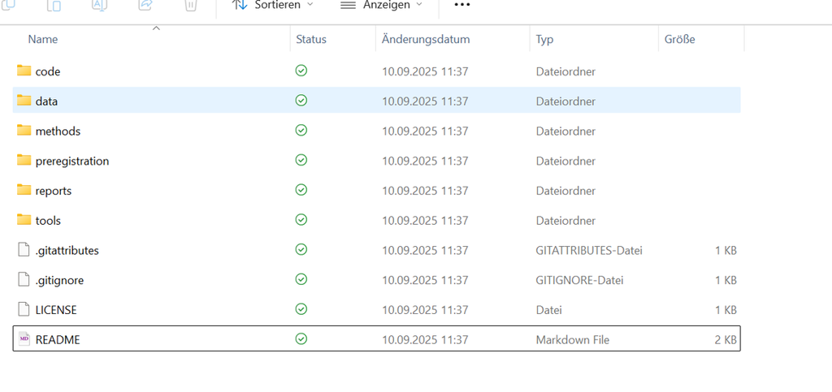

**Ein Standard von vielen Möglichen**

[Psych-DS](https://psychds-docs.readthedocs.io/en/latest/guides/1_getting_started/)

## Psych-DS für unsere Zwecke:

- Leicht Abgeändertes Format für unser Seminar
  - Macht es leichter für uns die Abgaben zu kontrollieren
- Hilft euch eine übersichtliche Ordnerstruktur zu behalten

## Psych-DS: Wichtigste Grundsätze

- Datensätze nur in “data”.
  - Die Rohdatenfiles werden nicht bearbeitet!
  - Der aufbereitete Datensatz -> data/processed
- Codebook in Ordner “data”
- Datenanalyseplan in “preregistration”
- Skripte in “code”
  - Aufbereitungsschritte im Skript “processing”
  - Analyse (mit dem processed datensatz) im Skript “analysis”
- Keine Redundanzen!
  - Keine redundanten Dateien
  - Keine redundanten Pakete (Nur Pakete laden, die auch verwendet werden).

## Psychdsish & Styler

- **📦 Packages** welche helfen sollen Psych-DS Struktur & Stylevorgaben leichter einzuhalten.
- Für Masterarbeiten: [Psychdsish](https://github.com/ianhussey/psychdsish?tab=readme-ov-file)

  Funktionen wie: `create_project_skeleton()`, `check_unused_objects()`, `validator()`
- **🥅 Ziel**: Einhaltung von Standards erleichtern
- **👗Styler**: Funktion um “unschön” formatierten Code leserlicher zu machen. 👉 Hands On!

## Wiederholung: Benennung von Variablen ect. in R

- Namen können aus Buchstaben, Zahlen und Zeichen (_ oder .) bestehen
- Er muss mit Buchstaben begonnen werden und darf keine Leerzeichen beinhalten
- Sonderzeichen und Großbuchstaben sollten vermieden werden Keine Namen verwenden, die schon an Funktionen vergeben sind (z.B. mean())
- Empfehlung für einen leserlichen Code: snake_case
- Name soll Variable inhaltlich bestmöglich beschreiben
- Reproduzierbarkeit; „clarity instead of brevity“
- Benennung am besten in Englisch um internationalen Standards zu folgen
- Kommentierung von R-Code mit #
  - Text nach # wird ignoriert (für 1 Zeile)
  - Neue Zeilen müssen wieder mit # beginnen

## Weitere Style Konventionen:

- Leerzeichen:
  - Vor und nach mathematischen Operatoren: `2+2` vs `2 + 2`
  - Vor und nach Zuweisungen: `x<-sum(1+2)` vs `x <- sum(1 + 2)`
  - Aber nicht vor und nach sich öffnenden oder schließenden Klammern oder Anführungszeichen
  - Nach Kommas (aber nicht davor)
  - Weitere Leerzeichen erlaubt wenn die Leserlichkeit erhöht (z.B. bei Einrückungen)
- Verwendung des Pipe Operators (`%>%` oder **`|>`** ) –> Erklärung folgt in kommenden Wochen!
- Zeilenumbrüche für langen Code verwenden

  ```r
  this_is_a_very_long_function_name <- (something = "this", requires = "many", arguments = "long words and sentences") #–> bad

  this_is_a_very_long_function_name <- (something = "this",
                                        requires = "many",
                                        arguments = "long words and sentences") #–> good
  ```

- Styler: Funktion die Code automatisch in dieses Format bringt. –> Hands On!

## Weitere Style Konventionen:

📖 **Lesbarkeit für Menschen und Maschine**

🧑‍💻 **Für Menschen:** Verwende aussagekräftige Dateinamen, die klar beschreiben, was in der Datei enthalten ist.

💻 **Für Maschinen:** Vermeide Leerzeichen, Sonderzeichen und Symbole in Dateinamen – bleibe bei Buchstaben, Zahlen und Unterstrichen.

🔢 **Struktur:** Benenne Dateien so, dass sie auch mit der Standard-Sortierung von Ordnern sinnvoll angeordnet werden. Ein bewährter Ansatz ist, mit Zahlen zu beginnen, um eine logische Reihenfolge abzubilden.

## Codebook

- Naive Personen sollen Datensatz nachvollziehen können (Reproduzierbarkeit & Zusatzanalysen)
- Beinhaltet eine Liste und Beschreibung aller Variablen
  - Wie wurde die Variable erhoben (z.B. aus welchem Fragebogen)?
  - Wie wurde die Variable berechnet (z.B. Summenscore, Mittelwert)?
  - Welche Werte kann die Variable annehmen (theoretisches Minimum und Maximum)?

## Wichtige Grundsätze für das Codebook

- Am besten für Rohdaten als auch weiter-verarbeitete Daten
- Variablennamen in Codebook sollen identisch zu Variablennamen in Datensatz sein
- Variable muss ausführlich genug beschrieben sein, sodass andere Personen es nachvollziehen können

## Codebook: Vorlage

- Kann in verschiedenen Formaten erstellt werden (Word, Excel, ect.)
- Excel-Vorlage für das Seminar (siehe ZIP Datei Abschlussprojekt)
- Beispiel: “Example_Codebook” - Ordner
- Für weitere Anleitungen siehe “Guideline Codebook”.

Siehe auch: Pennington (2023)

## Rohdaten für Grinschgl et al. (2020)

- Bereits vorhanden in euren Ordnern (r_you_ready)
- Wir mergen diese heute oder in EH4 zu einem vollständigen Datensatz –> **dat_full**

[figure not shown]

## Codebook

- Notwendig für „gemergten“ Datensatz „dat_full“
- Vorlage ist auf Englisch, kann aber auch auf Deutsch ausgefüllt werden (selbes gilt für Datenanalyseplan)
- Basierend auf Horstmann et al. (2020)
- Abgabe bis EH6 (22.10) über ILIAS und via Email an Peer-Partner:in
- Danach Peer Feedback

## Beispiel Codebook BFI

**Demo Beispiel:**

- Wir fügen nun live einige Variablen in das Codebook ein. Versucht die Schritte nachzuvollziehen und stellt Fragen bei Unklarheiten.

## Reproduzierbare Auwertung: Grundsätze

- Digitale Rohdaten
- Skript soll den gesamten Weg von den Rohdaten bis hin zu den Ergebnissen dokumentieren
- Wenn man euren Code auf den Rohdaten laufen lässt, sollte man (fehlerfrei) zu den Ergebnissen kommen
- Skript ist kommentiert und sinnvoll gegliedert

## Hands on!

- Projekte
- Daten einlesen
- Daten speichern

## Heute haben wir…

… Uns mit den Grundlagen von Forschungsdatenmanagement beschäftigt

… Psych-DS als einen Standard kennengelernt

…Style-Empfehlungen für R Code besprochen

…die Gründe für und den Aufbau von einem Codebook besprochen

…Datensätze in R importiert

…diese gemerged und exportiert (Fortsetzung in EH 4)

## Hausübungen

- Codebook erstellen bis **Mi 22.10.2025**
- Reminder: Datenanalyseplan bis **Mi 08.10.2025**

## Literatur:

Horstmann, K. T., Arslan, R. C., & Greiff, S. (2020). Generating Codebooks to Ensure the Independent Use of Research Data: Some Guidelines. *European Journal of Psychological Assessment*, *36*(5), 721–729. https://doi.org/10.1027/1015-5759/a000620

Pennington, C. R. (2023). *A student’s guide to open science: Using the replication crisis to reform psychology*. McGraw Hill.